# CHAPTER A20

# 胴体応力解析入門

## A20.1 概要

一般に飛行機の目的は、商業的な有料荷重（ペイロード）または軍事的に有用な荷重を輸送することである。現代の旅客機の商業的有料荷重は、100人以上の旅客とその手荷物である場合がある。これらの旅客は安全かつ快適に輸送されなければならない。たとえば、旅客機は気温が氷点下をはるかに下回り、空気密度が人間の生命を維持できないような高高度を飛行する。これらの事実は、旅客を運ぶ機体が、必要な安全を提供するために加熱、換気、および加圧されなければならないことを意味する。空の旅は旅客にとって受け入れられるものでなければならず、したがって飛行機の機体は旅客を過度の騒音や振動から保護しなければならず、さらに、移動中の旅行を快適で楽しいものにするために、効率的で落ち着きのある魅力的な調度品を提供しなければならない。旅客や有料荷重を収容する飛行機の部分は、胴体（フューゼラージ）と呼ばれる。胴体は、サイズや形状において大きく異なる。たとえば、超音速軍用機の胴体には、乗客が1人（パイロット）しか搭乗しない場合があり、胴体内部スペースの残りの部分は、推進装置の収容、着陸装置の格納スペースの提供、および飛行機を飛行させ、飛行機が実行するように設計されたさまざまな運用を実行するために必要な多くの機械的および電子的インストレーションを収容するために使用される。したがって、さまざまな教育訓練や経験の背景を持つ多くのエンジニアのグループが胴体の設計に関与している。構造エンジニアは、胴体構造の強度、剛性、および軽量化に対して責任を負うため、非常に重要な役割を果たす。

## A20.2 荷重。基本構造。

翼は揚力を発生させる物体であるため、大きな分布表面空気力にさらされるのに対し、胴体は比較的微小な表面空気力にさらされる。胴体は、翼反力、着陸装置反力、尾翼反力などの大きな集中力にさらされる。さらに、胴体にはさまざまなサイズや重量の多くのアイテムが収容されているため、胴体は大きな慣性力にさらされる。さらに、高高度飛行のため、胴体は内部圧力に耐えなければならず、これらの内部圧力を効率的に処理するには、円形断面または円形要素の組み合わせが必要となる。

学生は、航空機への荷重に関するさらなる議論については第A4章を、また胴体のせん断力とモーメントの計算例が提示されている第A5章を参照されたい。

基本的な胴体構造は、本質的に、多くの横方向のフレームまたはリングと縦方向のストリンガーを備えた単一セルの薄肉管であり、多くの集中および分布適用力を安全かつ効率的に吸収および伝達できる結合構造を提供する。胴体は、本質的に曲げ、ねじり、および軸力を受ける梁構造である。理想的な胴体構造は、切り欠きや不連続部のないものであるが、実際の胴体には多くの切り欠きが必要である。図 (a) は、外板を取り除いた小型飛行機の基本的な内部胴体構造を示している。これは横フレームと縦ストリンガーで構成されている。写真 1、2、および 3 は、最近の大型航空機の胴体構造を示している。

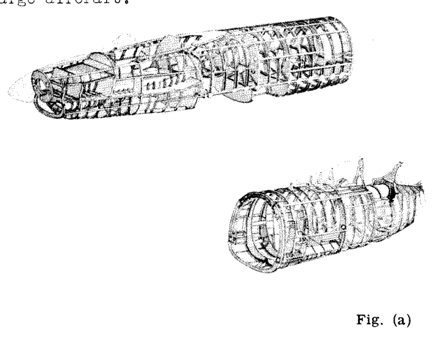

図 (a)

[figure not shown]

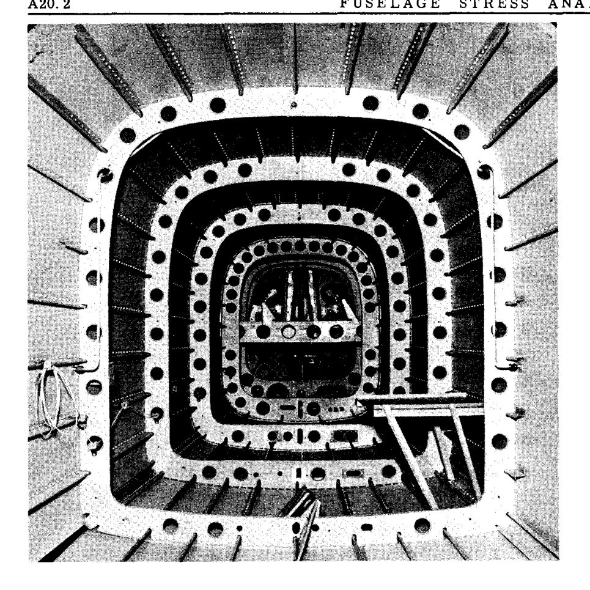

写真 2

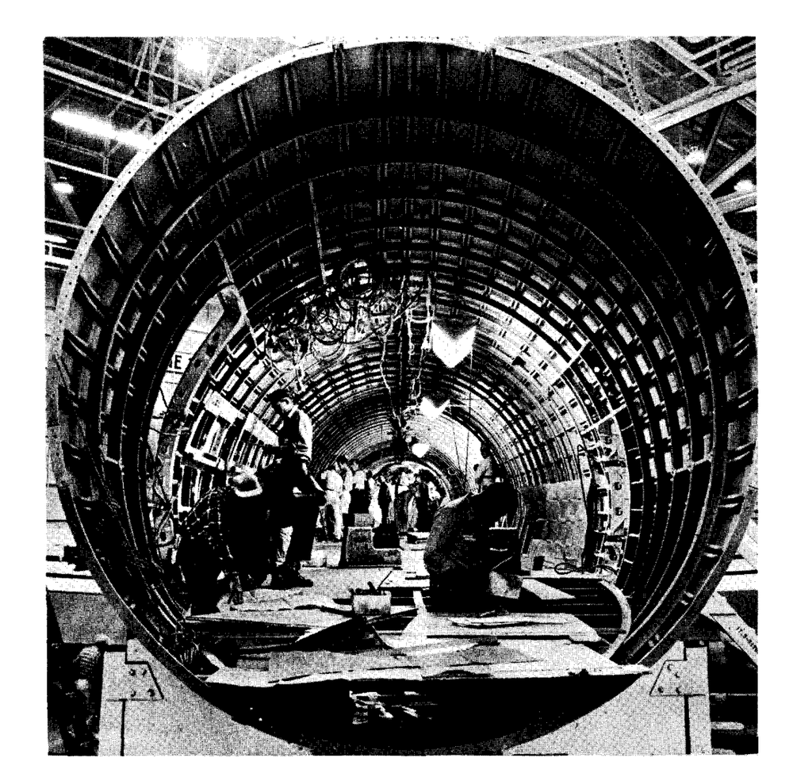

写真 3

（ダグラス DC-8 の胴体構造の一般的な詳細については、A15.32 ページを参照）

## A20.3 応力解析方法。有効断面。

胴体構造の外板およびストリンガーの応力を計算する際には、簡易梁理論を使用するのが一般的である。胴体が加圧されている場合、この内部圧力による外板の応力を、飛行荷重に抵抗する応力に加算しなければならない。翼では、翼型の中央領域の外板は比較的平坦であるため、通常、外板は平坦な板パネルで構成されていると見なされる。しかし、胴体では、外板は湾曲しており、湾曲した板パネルは、同じサイズおよび厚さの平坦なパネルよりも高い臨界圧縮座屈応力を持つ。小型飛行機では、胴体外板の曲率半径が比較的小さいため、この曲率による追加の座屈強度が著しくなることがある。外板曲率の影響を近似的に含める簡単な手順を以下に説明する。

図 A20.1 は、分布ストリンガー型の胴体断面を示している。外力が発生し、セルの上部に圧縮が生じるような、Y軸まわりの梁の曲げが発生すると仮定する。

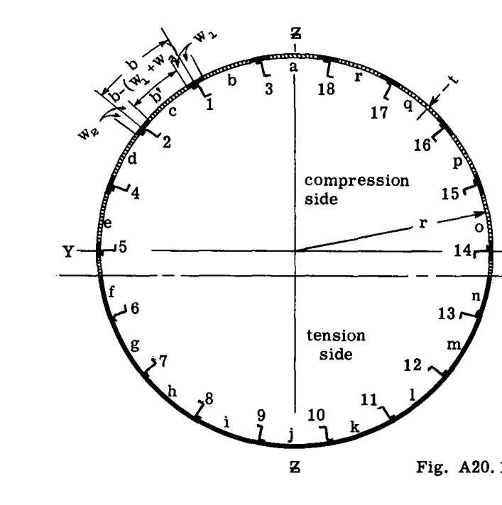

図 A20.1

外板ストリンガー間の湾曲した外板が座屈する点までは、梁断面のすべての材料を完全に有効であるとみなすことができ、曲げ応力は一般的な曲げ公式

$$\sigma_b = \frac{Mz}{I_y}$$

によって計算できる。ここで、 $I_y$ は断面全体の図心慣性モーメントである。ストリンガー間の湾曲した外板を座屈させる曲げ圧縮応力に達すると、断面全体の応力分布に再配置が行われる。理論および実験結果は、エッジストリンガーを持つ湾曲した外板の極限圧縮強度が、次の2つの仮定によって近似できることを示している。

1. ストリンガーへの外板の取付線の各側における外板の小さな幅 $w_1$ は、第A19章で説明したように、ストリンガーと同じ圧縮応力を負担すると見なされる。これらの有効外板幅 $w_1$ は、図 A20.1 の圧縮側において、ストリンガーに隣接する黒く塗られた要素として示されている。
2. ストリンガー間の湾曲した外板の残りの部分、すなわち $b - (w_1 + w_2)$ は、最大圧縮応力 $\sigma_{cr} = 0.3 E t/r$ を負担する。この $\sigma_{cr}$ の値は安全側である。 $E$ は外板材料の縦弾性係数、 $t$ は外板の厚さ、そして $r$ は外板の曲率半径である。これらの湾曲した外板要素は、図 A20.1 のハッチングされた外板長さによって示されている。

ストリンガー間の薄い湾曲外板は、通常、ストリンガーの座屈強度をはるかに下回る圧縮応力の下で座屈するため、湾曲した板は、胴体断面の曲げに対してその点に存在する曲げ応力 $\sigma_b$ に対する湾曲板の座屈応力 $\sigma_{cr}$ の比に依存する、変化する有効厚さを持つ要素として扱われる。したがって、湾曲した外板パネルの有効外板厚さは次のように書くことができる。

$$t_e = t \left( \frac{\sigma_{cr}}{\sigma_b} \right) \quad \text{--- (1)}$$

または、有効面積は次のように書くことができる。

$$A_e = b' t \left( \frac{\sigma_{cr}}{\sigma_b} \right) \quad \text{--- (2)}$$

ここで、 $b'$ は有効外板幅 $w_1$ , $w_2$ などの間の湾曲した外板の幅である（図 A20.1 を参照）。

胴体断面の有効断面を得る上でのこのアプローチを説明するために、例題を提示する。例題は、設計手順を学生に紹介する目的で、ある程度拡張される。

## A20.4 例題

図 A20.2 に示す近似楕円形状の胴体断面に対して、ストリンガー配置を決定することが求められているとする。

次のデータが想定される。 - Y軸まわりの設計曲げモーメント = 1,600,000 in. lb.（上部に圧縮を生じさせる）。 - 深さ1インチ、断面積 0.12 sq. in. のZ形ストリンガーを使用するものとする。 - Z形ストリンガーとその有効外板を合わせた極限圧縮強度、および胴体フレーム間隔に等しい長さは 32000 psi と想定される。 - 外板の厚さは .032 であり、すべての材料は $E = 10,300,000$ psi の（2024）アルミニウム合金である。 - 胴体ストリンガーは、断面の中心線に対して対称でなければならない。

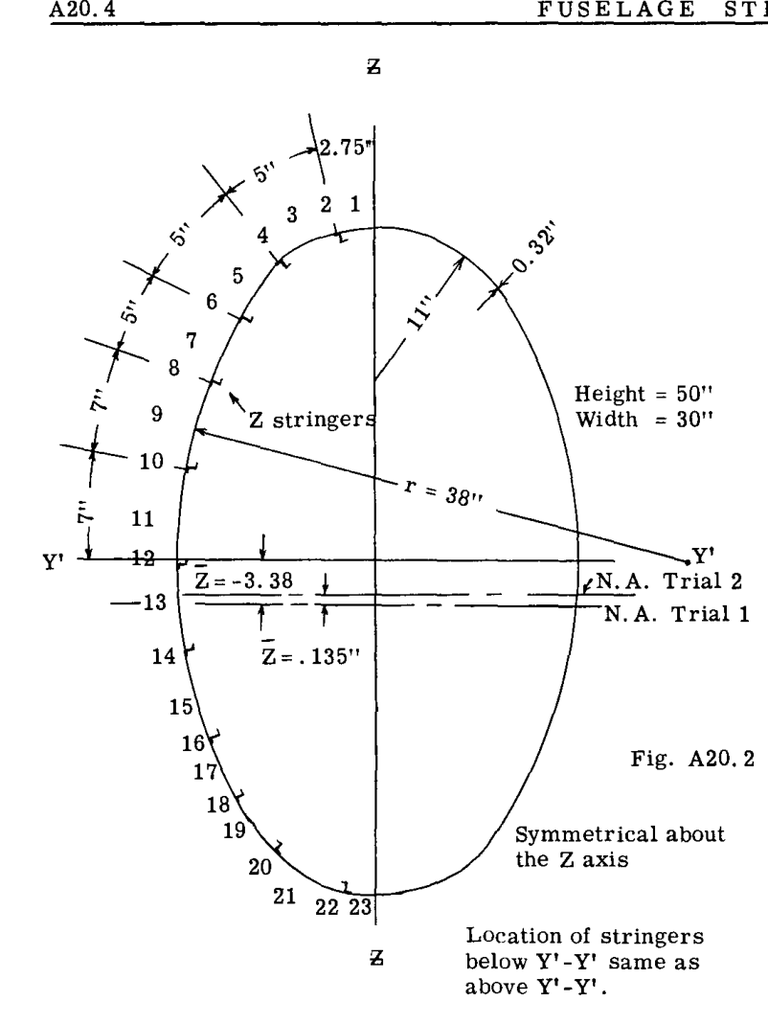

図 A20.2

### 解答

最初に行うべきことは、検討用の断面を得るために、およそ何本のZ形ストリンガーが必要になるかを決定することである。内部抵抗モーメントは外部曲げモーメントに等しくなければならないため、総圧縮フランジ応力と有効内部偶力アームの観点から内部抵抗偶力を予測することができる。

分布フランジ材料を持つ楕円および円形断面の場合、内部偶力の近似有効抵抗アームは高さ $h$ の 0.75 倍、平均引張または圧縮応力は最大応力の 2/3 として取ることができる。したがって、外部曲げモーメントを内部抵抗モーメントに等しく置くことにより、胴体断面の圧縮側の近似総断面積 $A_c$ を得ることができる。

$$M_y = A_c (0.67 \sigma_b) (0.75 h)$$

これより、

$$A_c = \frac{1,600,000}{0.75 \times 50 \times 0.67 \times 32000} = 2.0 \text{ sq. in.}$$

この総面積の一部は、有効外板面積によって提供される。各リベットラインで使用する有効幅は $w = C t \sqrt{E/\sigma_{st}}$ に等しい。一般的に使用される値である $C = 1.7$ を採用する。

$$w = 1.7 \times 0.032 \sqrt{10,300,000 / 32000} = 0.975 \text{ in.}$$

これは、 $0.975 / 0.032 = 30.5$ 倍の外板厚さに相当する。中立軸に近づくにつれて曲げ応力はゼロに減少し、また Z ストリンガー間の湾曲外板はその座屈強度までの荷重を負担できるため、各ストリンガーとともに作用する有効幅の予備値 $w = 40t$ を仮定する。したがって、ストリンガーと有効外板を合わせた総面積は $0.12 + 40 \times 0.032^2 = 0.16$ sq. in. に等しくなる。したがって、必要なストリンガーの数は $2.00 / 0.16 = 12$ となる。

図 A20.2 は、上半分に 12 本のストリンガーを与えるようにストリンガーがどのように配置されたかを示している。下半分の外板は引張状態にあり、したがって完全に有効であるため、中立軸は中心線より下に下がり、したがって中心線上の 2 本のストリンガーは必要な 12 本のストリンガーの一部とみなされる。これで胴体断面が得られた。望ましい最終結果は、最大圧縮応力が 32000 psi に近く、かつそれを超えないことである。これ以降の手順は、圧縮側の有効外板が圧縮曲げ応力の大きさに依存し、それがさらに有効外板の量と湾曲外板によって運ばれる座屈荷重に影響されるため、依然として試行錯誤（トライアル・アンド・エラー）のプロセスである。

図 A20.2 の予備的なストリンガー配置を使用して、表 A20.1 および A20.2 は、水平中立軸に関する断面の有効慣性モーメントの計算を示している。表 A20.1 はストリンガーと有効外板要素を扱い、表 A20.2 は湾曲した座屈外板要素を扱っている。

試行 No. 1 では、以下の仮定が行われる。

1. 上部すなわち圧縮側において、各ストリンガーとともに作用する外板の幅を、外板厚さの 30 倍とする。
2. 1. で求められた有効外板幅の間の湾曲外板の面積は、係数 $K = \sigma_{cr}/\sigma_b$ を乗じることによって有効面積を与えるように修正される。ここで $\sigma_{cr}$ は圧縮座屈応力であり、 $\sigma_b$ は湾曲外板要素の中心における曲げ応力であり、梁断面の最上部繊維で 32000、水平中心線でゼロと仮定し、これらの点の間で線形変化するものとする。

注意：下半分の外板全体が有効であるため、より論理的な仮定は、中立軸の位置を推測し、中立軸と最外縁繊維の間で $\sigma_b$ の変化を使用することである。このアプローチは、この例では使用しない。

### 表 A20.1

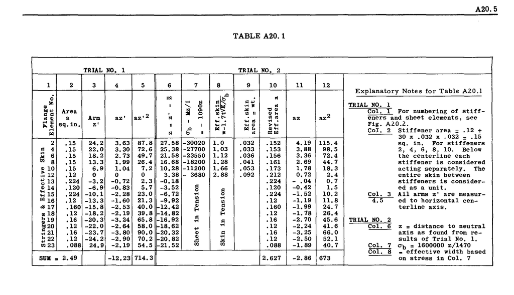

TABLE A20.1

### 表 A20.2

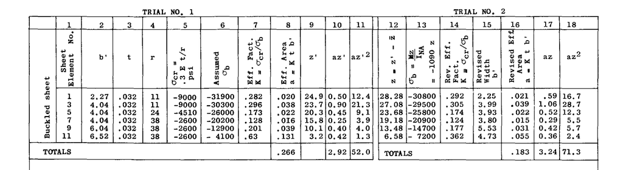

TABLE A20.2

### 試行 No. 1 の結果

両方の表の結果を考慮し、セルの半分だけが考慮されているため 2 を乗じる。

$$\sum a = \text{総有効面積} = (2.49 + 0.266) \times 2 = 5.51 \text{ sq. in.}$$

$$\sum a z' = (-12.23 + 2.92) \times 2 = -18.62$$

$$\bar{z} = \frac{\sum a z'}{\sum a} = \frac{-18.62}{5.51} = -3.38\text{"}$$

$$I_{NA} = 2(714.3 + 52) - 5.51 \times 3.38^2 = 1470 \text{ in.}^4$$

### 試行 No. 2 の結果

$$\text{総有効面積} = (2.627 + 0.183) \times 2 = 5.62$$

$$\sum a z' = (-2.86 + 3.24) \times 2 = 0.76$$

$$\bar{z} = \frac{0.76}{5.62} = 0.135\text{" （試行 1 の中立軸の上方）}$$

$$I_{NA} = 2(673 + 71.3) - 5.62 \times 0.135^2 = 1489$$

断面の対称性により、表 A20.1 および A20.2 は材料の半分についてのみ計算を行っているため、結果は 2 倍される。一般的な説明注記は各表の下に示されている。

試行 No. 1 の結果は、中心線より 3.38 インチ下の中立軸と、 $1470 \text{ in.}^4$ の慣性モーメントを与える。試行 No. 2 では、有効外板幅は 1470 の慣性モーメントに基づいている。試行 No. 2 の結果は、最初の位置より 0.135 インチ上の中立軸を伴う $1489 \text{ in.}^4$ の慣性モーメントを与える。1489 の慣性モーメントを利用して第 3 の試行を使用した場合、応力の小さな変化が有効外板幅に及ぼす影響は無視できるため、変化は非常に小さいものとなる。

したがって、得られた慣性モーメントと中立軸位置を使用したストリンガー No. 2 の圧縮応力は次のようになる。

$$\sigma_b = \frac{My Z}{I_y} = \frac{1,600,000 \times 27.45}{1489} = 29,500 \text{ psi}$$

許容応力は 32000 であったため、安全マージン（MS）は $(32000/29500) - 1 = 0.08$ すなわち 8% である。より小さな安全マージンが望まれる場合は、一部の材料が排除され、表 A20.1 および A20.2 の計算が繰り返されることになる。

### 中立軸における外板のせん断流の計算

外板のある点におけるせん断流 $q$ の方程式は次のとおりである。

$$q = q_0 - \frac{V_z}{I_y} \sum a z \quad \text{--- (3)}$$

Z軸に対する断面の対称性により、中心線 Z 軸上の点におけるせん断流 $q_0$ はゼロである。Z軸上の点と中立軸の間の $az$ 項の和は、表 A20.3 に示されている。面積 ( $a$ ) とアーム ( $z$ ) の値は、表 A20.1 および A20.2 から取得される。

### 表 A20.3

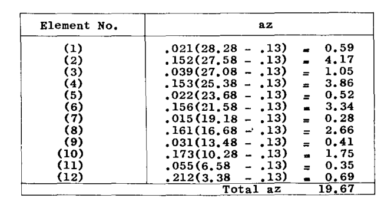

TABLE A20.3

式 (3) に代入すると、

$$q_{N.A.} = q_0 + \frac{V_z}{I_y} \sum a z$$

$$= 0 + \frac{V_z}{1489} 19.67 = 0.0132 V_z \text{ lb./in.}$$

せん断応力は $\tau = q/t = 0.0132 V_z / 0.032 = 0.413 V_z$ となる。

断面の平均せん断応力は $\tau_{av} = V_z / 2ht = V_z / (2 \times 50 \times 0.032) = 0.312 V_z$ となる。

したがって、この断面形状およびストリンガー配置の場合、最大せん断応力は平均せん断応力の $0.413 / 0.312$ 倍、すなわち約 4/3 倍の大きさになる。

上記の手順は、応力とひずみの線形変化が仮定されており、最遠のストリンガーがその極限圧縮応力に達したときに断面の破壊が発生すると仮定されているため、真のまたは実際の安全マージンに対してかなり安全側である。実際、胴体を破壊に至らせる静的試験において、1本のストリンガーが座屈しても胴体断面全体は崩壊せず、他のストリンガーがそれらの極限強度に達するまで荷重を増加させ続ける。さらに、典型的な胴体構造では、さまざまなサイズ、形状、したがって異なる圧縮強度を持つストリンガーが使用されるため、胴体断面の極限強度のより良い測定値を得るために、ストリンガーの有効性を測定するための応力手順の修正が行われる。この主題は、第A19章の第11節および第12節で詳細に議論された。胴体曲げ応力解析におけるストリンガーの有効性を示すために、簡単な例題を提示する。

## A20.5 胴体断面の極限曲げ強度。計算例。

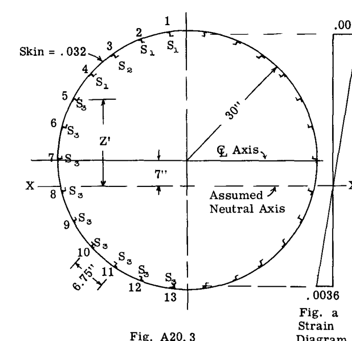

図 A20.3

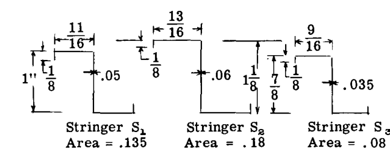

図 A20.4

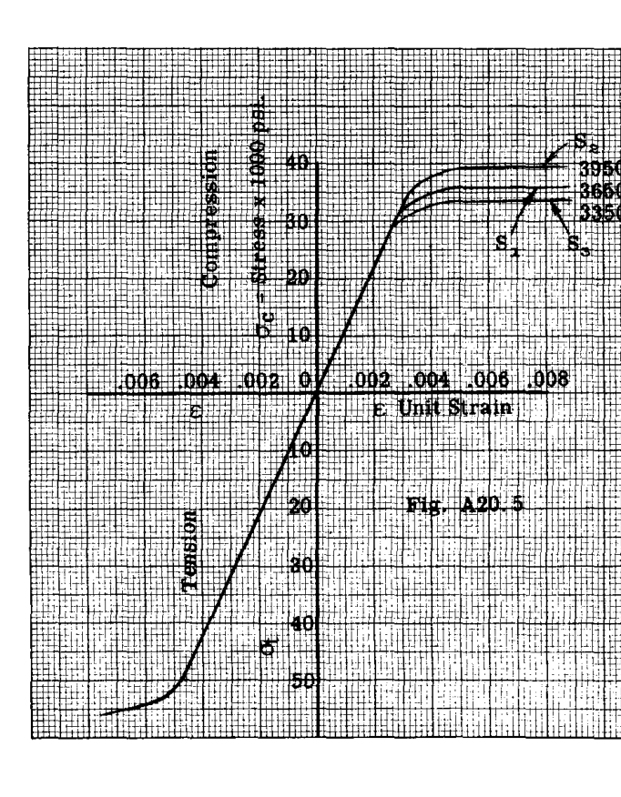

図 A20.5

図 A20.4 に示すように、3つのサイズのZ形ストリンガーが使用され、 $S_1$ 、 $S_2$ 、および $S_3$ とラベル付けされている。これらの記号は、各タイプのストリンガーがどこで使用されているかを示すために、図 A20.3 で使用されている。断面の各側のストリンガーには、図 A20.3 に示すように 1 から 13 までの番号が付けられている。図 A20.5 は、胴体フレーム間隔に等しい柱の長さで圧縮荷重を加えられた3つのストリンガータイプの応力-ひずみ曲線のプロットを示している。図 A20.5 は、材料であるアルミニウム合金（2024）の引張応力-ひずみ線図も示している。極限曲げ強度は、上部を圧縮状態にする曲げについて計算される。

中立軸の位置は未知であるため、位置を仮定する。すなわち、図 A20.3 に示すように、中心線軸から 7 インチ下方とする。有効慣性モーメントを決定するための計算全体は、表 A20.4 に示すように、表形式で行うのが最適である。Z軸に関する対称性により、結果は2倍にできるため、構造の半分だけを考慮すればよい。

列 (1) は位置に関するストリンガー番号を示し、列 (2) はタイプ $S_1$ , $S_2$ , $S_3$ に従った分類を示す。列 (3) はストリンガーの面積を与える。断面の引張側または下側では、外板はすべて有効であり、各隣接ストリンガーへの中間の外板エリアが、番号 9 から 13 のストリンガーとともに作用すると仮定され、この外板面積は列 (5) に記録される。圧縮側では、外板は部分的にしか有効ではない。各ストリンガーリベットラインの有効幅 $w$ は、ストリンガー応力に依存する。有効幅 $w = 1.9t\sqrt{E/\sigma_{ST}}$ とする。有効面積 $A_e$ は $wt$ に等しくなる。これらの有効外板面積は列 (5) に記録される。この方程式を解くにあたり、ストリンガー応力 $\sigma_{ST}$ は、ストリンガー番号 (1) で -36500 psi とされ、列 (4) に示すように中立軸でゼロまで線形に変化するものとする。この仮定は正確ではないが、有効外板面積を得るためには十分に正確である。説明のために、ストリンガー番号 (1) を考慮する。有効面積 $A_e$ は次のように計算される。

$$A_e = w t = 1.9 t^2 \sqrt{E/\sigma_{ST}}$$

$$= 1.9 \times 0.032^2 \sqrt{10,300,000 / 36500} = 0.032 \text{ sq. in.}$$

列 (6) は、ストリンガーと有効外板の面積の合計、すなわち $A_s + A_e$ を与える。

この例題では、有効幅の間の湾曲外板パネルの有効性は、その影響が小さいため無視される。前の例題で示されたように、それを含めることも可能である。

応力を計算する際に梁公式 $\sigma_b = M_y Z/I_x$ を使用したいため、公式が線形応力変化に基づいているため、線形応力変化を与えるようにストリンガー面積を修正しなければならない。ストリンガー修正係数 $K$ は、表の列 (9) の真の応力と、列 (4) の線形応力値の比に等しい、すなわち $K = \sigma/\sigma'$ である。結果は列 (10) に記録される。修正されたストリンガー面積は $KA$ に等しくなり、列 (11) に記録される。列 (12) は、仮定された中立軸まわりの修正された面積の 1 次モーメントを与え、総和として -3.16 を与える。

### 表 A20.4

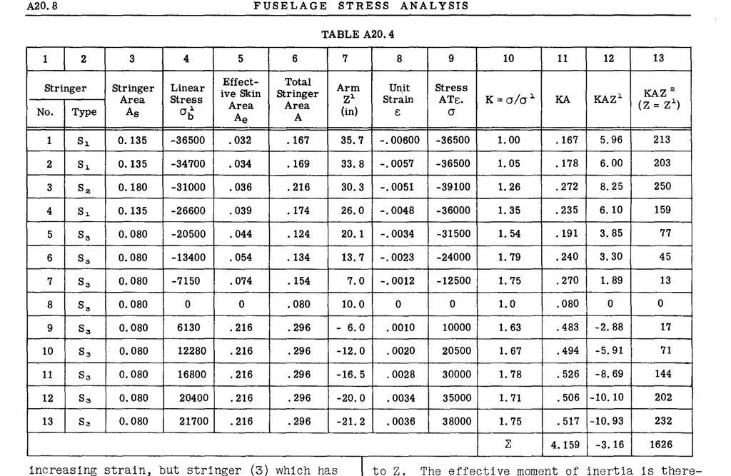

TABLE A20.4

仮定された中立軸から真の中立軸までの距離 $\bar{Z}$ は次のようになる。

$$\bar{Z} = \frac{\sum KA Z'}{\sum KA}$$

$$= \frac{-3.16}{4.159} = -0.76\text{"}$$

真の中立軸は、仮定された位置より約 0.70 インチ下に位置することになる。列 (13) の総和に及ぼす影響は無視できるため、表 A20.4 は改訂しない。

列 (13) は、 $Z'$ が $Z$ に等しい場合の有効慣性モーメントの計算を与えている。したがって、有効慣性モーメントは列 (13) の和の 2 倍、すなわち 3252 となる。

### 極限抵抗モーメントの計算

番号 (1) である最遠ストリンガーにおける最大応力は 36500 である。梁公式から、

$$M_x = \frac{\sigma_b I_x}{Z}$$

$$= \frac{36,500 \times 3252}{35.7 + 0.7}$$

$$= 3,260,000 \text{ in. lb.}$$

この曲げ強度を、X軸まわりの任意の設計曲げモーメントと比較すると、曲げ強度に対する安全マージンが得られる。

もし慣性モーメントが非線形応力変化を考慮せずに計算されていた場合、すなわち、すべてのストリンガーに対して $K = 1$ とした場合、中立軸は中心線軸より 4.9 インチ下になり、慣性モーメントは $2382 \text{ in.}^4$ と計算されていたはずである。その場合、発生する抵抗モーメントは $(36500 \times 2382) / 33.6 = 2,600,000$ in. lbs. となっていた。したがって、真の強度は線形応力変化基準の強度よりも 25% 大きい。この結果は、線形応力変化基準で設計された場合、そのような構造物が試験においてなぜ超過強度を示すのかを説明している。

ストリンガー応力が得られた後、表 A20.4 の修正された面積を使用して、せん断流解析で使用しなければならない真のストリンガー荷重を求めるために、真のストリンガー面積を使用しなければならない。

## A20.6 胴体構造のせん断流解析

胴体の有効断面が得られれば、せん断流解析を行うことができる。手順は、第A19章で翼構造について示されたものと同じである。説明のために、2つの例題を提示する。

### 例題 1. 対称テーパー断面

図 A20.6 は、小型飛行機の胴体の後部を代表する可能性のある、テーパー状の円形胴体構造の一部を示している。この例はせん断流解析を説明することのみを目的としているため、16本のストリンガーのみが有効な材料であると仮定する。実際の応力解析では、前の A20.3 節から A20.5 節で説明したように、有効断面を使用しなければならない。

問題は、図 A20.6 に示すように、ステーション (150) における与えられた荷重システムの下で、ステーション (0) におけるストリンガー応力と外板せん断流応力システムを決定することである。

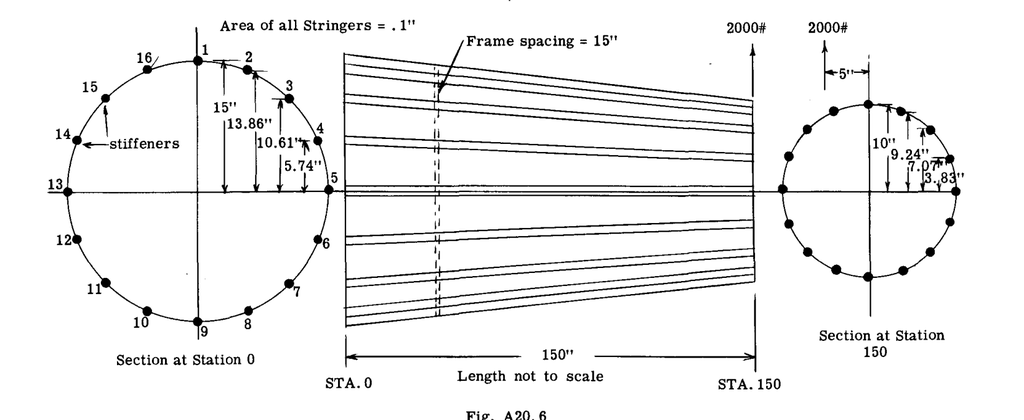

図 A20.6

### 解答 No. 1 - 1つの断面のみにおける梁の特性を考慮することによる解答

縦ストリンガーまたはフランジ材料の変化がかなり一様である場合、この方法は、得られるせん断流応力の誤差をほとんど伴わずに使用できる。

中心 Y 軸に関するステーション (0) における断面の慣性モーメントは以下の通りである。

$$I_y = (15^2 \times 0.1 \times 2) + (13.86^2 + 10.61^2 + 5.74^2) \times 0.1 \times 4 = 180 \text{ in.}^4$$

したがって、ステーション 0 における純ウェブせん断力は次のようになる。

$$V_{web} = V_{ext} + V_{flange} = 2000 + (2 \times -333.4) = 1333.2 \text{ lb.}$$

この特定の問題における結果は、ステーション 0 においてフランジストリンガーシステムが外部せん断荷重の 3 分の 1 に抵抗することを示している。ステーション 150 では、ストリンガーの荷重がゼロであるため、ウェブシステムが 2000 lb. の外部せん断荷重全体に抵抗する。

実際の設計では、多くの場合、必要な板厚を 1 ゲージ以上減少させることができるため、純ウェブせん断を使用する必要がある。

### たわみせん断流の計算

$$q = q_0 - \frac{V_{z(web)}}{I_y} \sum a z = q_0 - \frac{1333.2}{180} \sum a z$$

$$= q_0 - 7.40 \sum a z \quad \text{--- (A)}$$

Z軸に関する断面の対称性により、中心線におけるウェブのたわみせん断流はゼロである。したがって、 $q_0$ はゼロとみなされ、方程式 (A) の総和が行われる。